# Lab 3: Adversarial Examples Lab

### Introduction

In this lab, we will explore the concept of adversarial examples as introduced in the seminal paper by Goodfellow et al. (2015): "Explaining and Harnessing Adversarial Examples." Adversarial examples are inputs to machine learning models that have been subtly modified to cause the model to make a mistake, while appearing nearly identical to the original input from a human perspective.

### Objectives

1. Understand why neural networks are vulnerable to adversarial examples
2. Implement the Fast Gradient Sign Method (FGSM) to generate adversarial examples
3. Visualize how small, imperceptible perturbations can lead to high-confidence misclassifications

### Implementation

We'll train a simple deep learning model on the MNIST handwritten digit dataset, then apply FGSM to generate adversarial examples that fool our model.

### Setup Instructions

This notebook requires PyTorch and related libraries. If you encounter issues installing these dependencies locally, you can run this notebook in Google Colab, which provides these libraries pre-installed.

```python
import torch
import torch.nn as nn
import torch.optim as optim
import torchvision
import torchvision.transforms as transforms
import matplotlib.pyplot as plt
```

### Data Loading and Preprocessing

In this section, we set up the data pipeline for our experiment:

1. **Device Configuration**: We determine whether to use GPU (CUDA) or CPU for computation.
2. **Data Transformation**: We apply a simple transformation to convert the MNIST images to PyTorch tensors. Unlike many image classification tasks, we don't normalize the pixel values here because MNIST pixel values are already in the range [0,1] after ToTensor()
3. **Dataset Loading**: We load the MNIST dataset, which consists of 28×28 grayscale images of handwritten digits (0-9).
   - Training set: 60,000 examples
   - Test set: 10,000 examples
4. **DataLoader Creation**: We create DataLoader objects that will feed batches of data to our model during training and evaluation.
   - We use a batch size of 64
   - We shuffle the training data to improve model generalization

```python
device = torch.device("cuda" if torch.cuda.is_available() else "cpu")

transform = transforms.Compose(
    [
        transforms.ToTensor(),
    ]
)

batch_size = 64

train_dataset = torchvision.datasets.MNIST(
    root="./data", train=True, transform=transform, download=True
)
test_dataset = torchvision.datasets.MNIST(
    root="./data", train=False, transform=transform, download=True
)

train_loader = torch.utils.data.DataLoader(
    dataset=train_dataset, batch_size=batch_size, shuffle=True
)
test_loader = torch.utils.data.DataLoader(
    dataset=test_dataset, batch_size=batch_size, shuffle=False
)
```

### Display Data

```
Batch shape: torch.Size([64, 1, 28, 28])
Target shape: torch.Size([64])
```

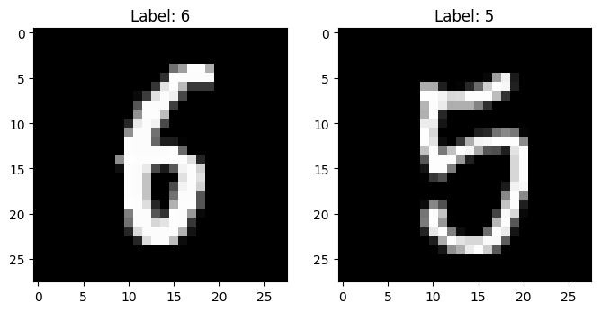

```python
examples = iter(train_loader)
example_data, example_targets = next(examples)

print(f"Batch shape: {example_data.shape}")  # Should be [batch_size, channels, height, width]
print(f"Target shape: {example_targets.shape}")  # Should be [batch_size]

fig, axes = plt.subplots(1, 2, figsize=(8, 4))
axes[0].imshow(example_data[0].squeeze(), cmap='gray')
axes[0].set_title(f'Label: {example_targets[0].item()}')
axes[1].imshow(example_data[1].squeeze(), cmap='gray')
axes[1].set_title(f'Label: {example_targets[1].item()}')
plt.show()
```

### Model Definition

Define a simple neural network for MNIST digit classification.

Implement a neural network architecture of your choice. For simplicity, we recommend starting with a Multi-Layer Perceptron (MLP) with the following structure:

1. An input layer that flattens the 28x28 MNIST images
2. A hidden layer with 64 neurons and ReLU activation
3. An output layer with 10 neurons (one for each digit 0-9)

For implementation, use PyTorch's nn.Module as the base class and implement:

- The `__init__` method to define your network layers
- The `forward` method to define how data flows through your network

For model components, refer to:

- [torch.nn.Linear](https://pytorch.org/docs/stable/generated/torch.nn.Linear.html)
- [torch.nn.ReLU](https://pytorch.org/docs/stable/generated/torch.nn.ReLU.html)

**Hint 1**

Remember to flatten the input images in the forward method. MNIST images come in shape [batch_size, 1, 28, 28] and need to be reshaped to [batch_size, 784]. Use x = x.view(x.size(0), -1) for this purpose.

**Hint 2**

When creating your first linear layer, the input size should be 784 (28×28×1) to match the flattened MNIST images.

```python
class Net(nn.Module):
    def __init__(self):
        super().__init__()

        self.model = nn.Sequential(
            nn.Flatten(),
            nn.Linear(784, 64),
            nn.ReLU(),
            nn.Linear(64, 10)
        )
    #

    def forward(self, x):
        # x = x.view(x.size(0), -1)
        return self.model(x)
#

model = Net().to(device)
initial_model_state = model.state_dict()
```

### Training the Neural Network

Below is a basic training loop for our MNIST classifier. We use CrossEntropyLoss as our loss function, which is the standard choice for multi-class classification problems. For optimization, we employ SGD (Stochastic Gradient Descent).

The training process consists of:

1. Forward pass through the network
2. Loss calculation
3. Gradient computation via backpropagation
4. Parameter updates using the optimizer

```python
learning_rate = 1e-2

criterion = nn.CrossEntropyLoss()
optimizer = optim.SGD(model.parameters(), lr=learning_rate)

num_epochs = 10

model.train()
for epoch in range(num_epochs):
    running_loss = 0.0
    for images, labels in train_loader:
        images, labels = images.to(device), labels.to(device)

        # Forward pass
        outputs = model(images)           # Step 1: Get predictions
        loss = criterion(outputs, labels) # Step 2: Measure error
        # Backward pass and optimize
        optimizer.zero_grad()             # Step 3: Clear old gradients
        loss.backward()                   # Step 4: Compute new gradients
        optimizer.step()                  # Step 5: Update model weights

        running_loss += loss.item()

    print(f"Epoch [{epoch+1}/{num_epochs}], Loss: {running_loss/len(train_loader):.4f}")
```

```
Epoch [1/10], Loss: 1.3067
Epoch [2/10], Loss: 0.5086
Epoch [3/10], Loss: 0.3992
Epoch [4/10], Loss: 0.3563
Epoch [5/10], Loss: 0.3315
Epoch [6/10], Loss: 0.3130
Epoch [7/10], Loss: 0.2978
Epoch [8/10], Loss: 0.2849
Epoch [9/10], Loss: 0.2735
Epoch [10/10], Loss: 0.2634
```

### Model Evaluation

We evaluate our model's performance by measuring accuracy on the test dataset. This is a simplified approach - in a real environment, we would typically use a separate validation dataset and employ more comprehensive evaluation metrics. However, for the purposes of this notebook, this straightforward evaluation is sufficient to demonstrate the model's baseline performance before we explore adversarial examples.

We’re testing on ‘clean’ images (no tricks yet). A simple MLP should get ~90% accuracy — good, but not perfect.

```python
model.eval()
correct = 0
total = 0
with torch.no_grad():
    for images, labels in test_loader:
        images, labels = images.to(device), labels.to(device)
        outputs = model(images)
        _, predicted = torch.max(outputs.data, 1)
        total += labels.size(0)
        correct += (predicted == labels).sum().item()

clean_acc = 100 * correct / total
print(f"Accuracy on clean test images: {clean_acc:.2f}% (expect ~90%)")
```

```
Accuracy on clean test images: 92.87% (expect ~90%)
```

### Comparing Optimizer Performance

For a challenge, try training with Adam, and Adagrad. Plot their losses. Which converges fastest?

```python
def train_nn(
    model: nn.Module,
    train_loader: torch.utils.data.DataLoader,
    optimizer,
    criterion = nn.CrossEntropyLoss(),
    num_epochs: int = 10,
):
    model.train()

    loss_function_values = []
    for epoch in range(num_epochs):
        running_loss = 0.0
        for images, labels in train_loader:
            images, labels = images.to(device), labels.to(device)

            # Forward pass
            outputs = model(images)           # Step 1: Get predictions
            loss = criterion(outputs, labels) # Step 2: Measure error
            # Backward pass and optimize
            optimizer.zero_grad()             # Step 3: Clear old gradients
            loss.backward()                   # Step 4: Compute new gradients
            optimizer.step()                  # Step 5: Update model weights

            running_loss += loss.item()
        loss_function_values.append(running_loss)
        print(f"Epoch [{epoch+1}/{num_epochs}], Loss: {running_loss/len(train_loader):.4f}")
    return loss_function_values
#
```

```python
def eval_nn(
    model: nn.Module,
    test_loader: torch.utils.data.DataLoader
):
    model.eval()
    correct = 0
    total = 0
    with torch.no_grad():
        for images, labels in test_loader:
            images, labels = images.to(device), labels.to(device)
            outputs = model(images)
            _, predicted = torch.max(outputs.data, 1)
            total += labels.size(0)
            correct += (predicted == labels).sum().item()

    clean_acc = 100 * correct / total
    print(f"Accuracy on clean test images: {clean_acc:.2f}% (expect ~90%)")
#
```

```python
def plot_2d(
    X,
    y,
    ax: plt.Axes | None = None,
    title: str = "",
    xlabel: str = "",
    ylabel: str = "",
    label: str = "",
    figsize: tuple[int, int] = (10, 8)
) -> None:
    if ax is None: _, ax = plt.subplots(figsize=figsize)

    ax.plot(X, y, label=label)

    if title: ax.set_title(title)
    if xlabel: ax.set_xlabel(xlabel)
    if ylabel: ax.set_ylabel(ylabel)
    if label: ax.legend()
    plt.tight_layout()
#
```

```python
model.load_state_dict(initial_model_state)
optimizer = optim.Adam(model.parameters(), lr=learning_rate)
criterion = nn.CrossEntropyLoss()
num_epochs = 10

loss_function_values = train_nn(
    model,
    train_loader,
    optimizer,
    criterion,
    num_epochs=num_epochs
)
eval_nn(
    model,
    test_loader
)
```

```
Epoch [1/10], Loss: 0.2196
Epoch [2/10], Loss: 0.1367
Epoch [3/10], Loss: 0.1174
Epoch [4/10], Loss: 0.1028
Epoch [5/10], Loss: 0.0990
Epoch [6/10], Loss: 0.0901
Epoch [7/10], Loss: 0.0844
Epoch [8/10], Loss: 0.0845
Epoch [9/10], Loss: 0.0743
Epoch [10/10], Loss: 0.0738
Accuracy on clean test images: 96.17% (expect ~90%)
```

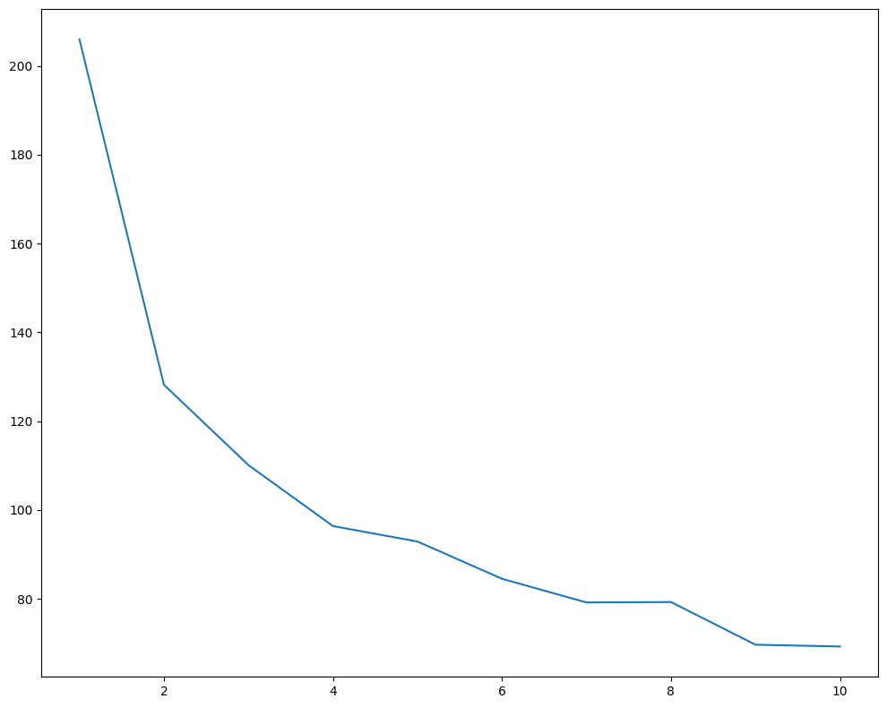

```python
plot_2d(
    range(1, num_epochs + 1),
    loss_function_values
)
```

```python
model.load_state_dict(initial_model_state)
optimizer = optim.Adagrad(model.parameters(), lr=learning_rate)
criterion = nn.CrossEntropyLoss()
num_epochs = 10

loss_function_values = train_nn(
    model,
    train_loader,
    optimizer,
    criterion,
    num_epochs=num_epochs
)
eval_nn(
    model,
    test_loader
)
```

```
Epoch [1/10], Loss: 0.0308
Epoch [2/10], Loss: 0.0211
Epoch [3/10], Loss: 0.0184
Epoch [4/10], Loss: 0.0168
Epoch [5/10], Loss: 0.0157
Epoch [6/10], Loss: 0.0148
Epoch [7/10], Loss: 0.0140
Epoch [8/10], Loss: 0.0134
Epoch [9/10], Loss: 0.0129
Epoch [10/10], Loss: 0.0125
Accuracy on clean test images: 97.54% (expect ~90%)
```

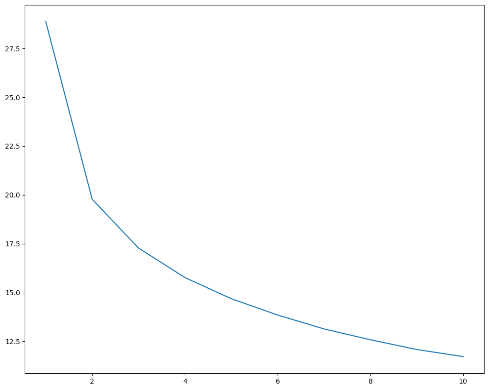

```python
plot_2d(
    range(1, num_epochs + 1),
    loss_function_values
)
```

### FGSM Attack

Implement FGSM attack.

```python
default_epsilon = 0.15

def fgsm_attack(
    model: nn.Module, images: torch.Tensor, labels: torch.Tensor, epsilon: float = default_epsilon
) -> torch.Tensor:
    """
    Creates adversarial examples via the FGSM method:
    x_adv = x + epsilon * sign( dJ/dx ).
    """
    images = images.clone().detach().to(device)
    labels = labels.to(device)

    # Ensure gradients are being tracked
    images.requires_grad = True

    # 1. Calculate outputs and loss
    # 2. Backpropagate loss (use backward method)
    # 3. Collect the element-wise sign of the data gradient (you can access it by images.grad.data.sign())
    # 4. Create the perturbed image
    # 5. Clamp to [0,1] if needed to ensure valid pixel range

    outputs = model(images)
    loss = nn.CrossEntropyLoss()(outputs, labels)

    model.zero_grad()
    loss.backward()

    grad_sign = images.grad.sign()

    adv_images = images + epsilon * grad_sign
    adv_images = torch.clamp(adv_images, 0, 1)

    return adv_images
#
```

### Calculate accuracy for adversarial examples

```python
correct = 0
total = 0
for images, labels in test_loader:
    # Generate adversarial images
    adv_images = fgsm_attack(model, images, labels, default_epsilon)

    # Re-classify
    outputs = model(adv_images.to(device))
    _, predicted = torch.max(outputs.data, 1)

    total += labels.size(0)
    correct += (predicted.cpu() == labels).sum().item()

adv_acc = 100 * correct / total
print(f"Accuracy on adversarial test images (FGSM, eps={default_epsilon}): {adv_acc:.2f}%")
```

```
Accuracy on adversarial test images (FGSM, eps=0.15): 33.26%
```

### Display adversarial examples

Let's compare original and adversarial images side-by-side.

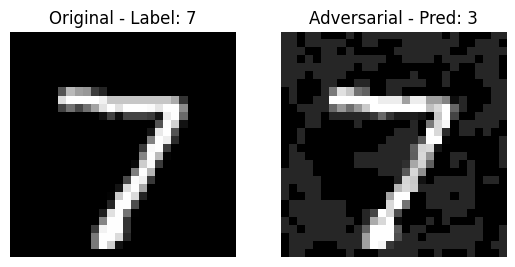

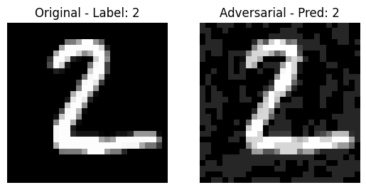

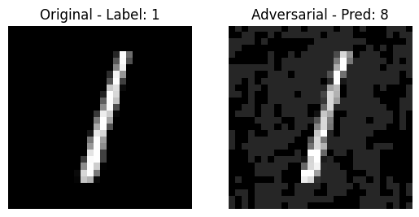

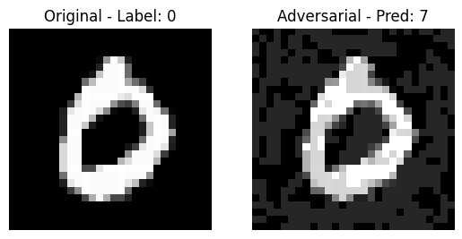

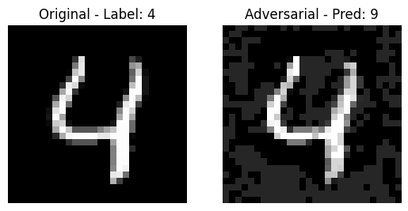

```python
examples = iter(test_loader)
example_images, example_labels = next(examples)
example_images = example_images[:5]
example_labels = example_labels[:5]

adv_ex = fgsm_attack(model, example_images, example_labels, default_epsilon)

for i in range(5):
    plt.figure()

    plt.subplot(1, 2, 1)
    plt.title(f"Original - Label: {example_labels[i].item()}")
    plt.imshow(example_images[i][0].cpu(), cmap="gray")
    plt.axis("off")

    adv_label_out = model(adv_ex[i].unsqueeze(0))
    _, adv_pred = torch.max(adv_label_out, 1)
    plt.subplot(1, 2, 2)
    plt.title(f"Adversarial - Pred: {adv_pred.item()}")
    plt.imshow(adv_ex[i][0].detach().cpu(), cmap="gray")
    plt.axis("off")

    plt.show()
```

### Epsilon Parameter Analysis

In this section, you'll analyze how the epsilon parameter affects the effectiveness of adversarial examples. The epsilon parameter controls the magnitude of the perturbation applied to the original images.

**Task:**

1. Evaluate the model's accuracy on adversarial examples generated with different epsilon values (try at least 5 different values)
2. Create a line plot showing model accuracy (y-axis) vs. epsilon value (x-axis)
3. Discuss the trade-off between:
- Visual perceptibility of the perturbations (higher epsilon = more visible changes)
- Attack success rate (higher epsilon = more successful attacks = lower model accuracy)

```
Accuracy on adversarial test images (FGSM, eps=0.01): 94.62%
```

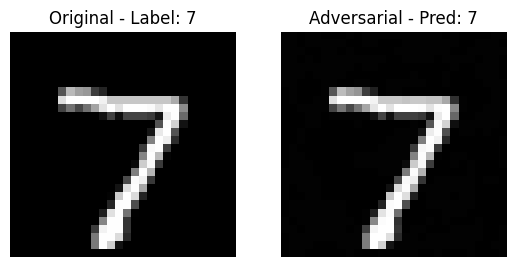

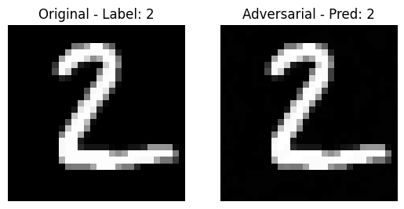

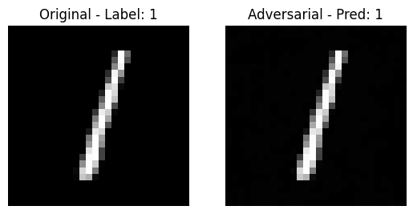

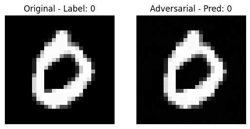

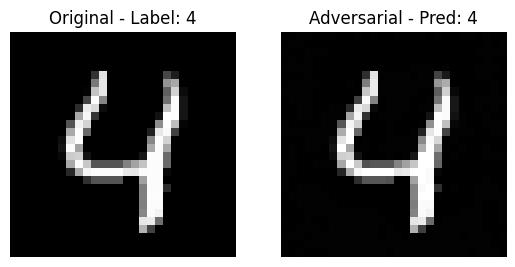

```python
eps = 0.01

correct = 0
total = 0
for images, labels in test_loader:
    # Generate adversarial images
    adv_images = fgsm_attack(model, images, labels, eps)

    # Re-classify
    outputs = model(adv_images.to(device))
    _, predicted = torch.max(outputs.data, 1)

    total += labels.size(0)
    correct += (predicted.cpu() == labels).sum().item()

adv_acc = 100 * correct / total
print(f"Accuracy on adversarial test images (FGSM, eps={eps}): {adv_acc:.2f}%")

###

examples = iter(test_loader)
example_images, example_labels = next(examples)
example_images = example_images[:5]
example_labels = example_labels[:5]

adv_ex = fgsm_attack(model, example_images, example_labels, eps)

for i in range(5):
    plt.figure()

    plt.subplot(1, 2, 1)
    plt.title(f"Original - Label: {example_labels[i].item()}")
    plt.imshow(example_images[i][0].cpu(), cmap="gray")
    plt.axis("off")

    adv_label_out = model(adv_ex[i].unsqueeze(0))
    _, adv_pred = torch.max(adv_label_out, 1)
    plt.subplot(1, 2, 2)
    plt.title(f"Adversarial - Pred: {adv_pred.item()}")
    plt.imshow(adv_ex[i][0].detach().cpu(), cmap="gray")
    plt.axis("off")

    plt.show()
```

```
Accuracy on adversarial test images (FGSM, eps=0.1): 43.41%
```

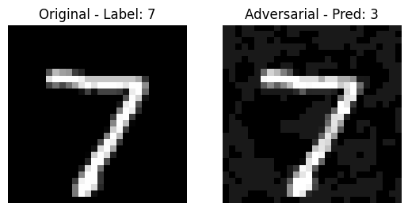

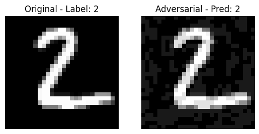

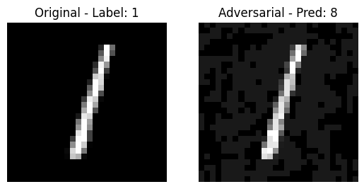

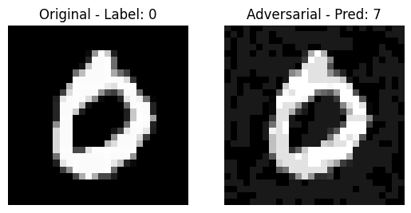

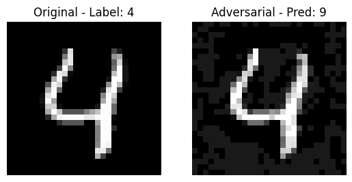

```python
eps = 0.1

correct = 0
total = 0
for images, labels in test_loader:
    # Generate adversarial images
    adv_images = fgsm_attack(model, images, labels, eps)

    # Re-classify
    outputs = model(adv_images.to(device))
    _, predicted = torch.max(outputs.data, 1)

    total += labels.size(0)
    correct += (predicted.cpu() == labels).sum().item()

adv_acc = 100 * correct / total
print(f"Accuracy on adversarial test images (FGSM, eps={eps}): {adv_acc:.2f}%")

###

examples = iter(test_loader)
example_images, example_labels = next(examples)
example_images = example_images[:5]
example_labels = example_labels[:5]

adv_ex = fgsm_attack(model, example_images, example_labels, eps)

for i in range(5):
    plt.figure()

    plt.subplot(1, 2, 1)
    plt.title(f"Original - Label: {example_labels[i].item()}")
    plt.imshow(example_images[i][0].cpu(), cmap="gray")
    plt.axis("off")

    adv_label_out = model(adv_ex[i].unsqueeze(0))
    _, adv_pred = torch.max(adv_label_out, 1)
    plt.subplot(1, 2, 2)
    plt.title(f"Adversarial - Pred: {adv_pred.item()}")
    plt.imshow(adv_ex[i][0].detach().cpu(), cmap="gray")
    plt.axis("off")

    plt.show()
```

```
Accuracy on adversarial test images (FGSM, eps=0.2): 27.01%
```

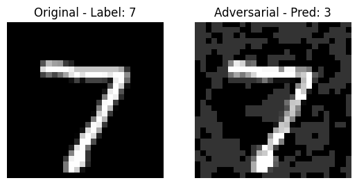

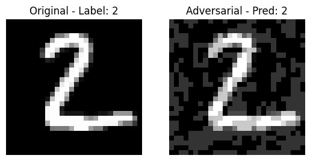

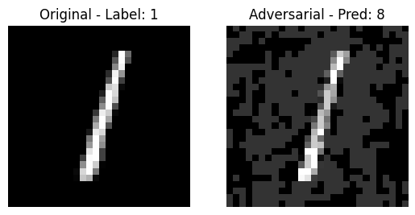

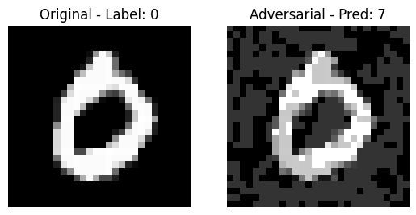

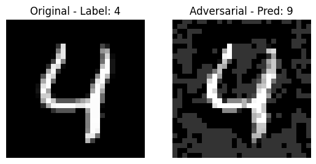

```python
eps = 0.2

correct = 0
total = 0
for images, labels in test_loader:
    # Generate adversarial images
    adv_images = fgsm_attack(model, images, labels, eps)

    # Re-classify
    outputs = model(adv_images.to(device))
    _, predicted = torch.max(outputs.data, 1)

    total += labels.size(0)
    correct += (predicted.cpu() == labels).sum().item()

adv_acc = 100 * correct / total
print(f"Accuracy on adversarial test images (FGSM, eps={eps}): {adv_acc:.2f}%")

###

examples = iter(test_loader)
example_images, example_labels = next(examples)
example_images = example_images[:5]
example_labels = example_labels[:5]

adv_ex = fgsm_attack(model, example_images, example_labels, eps)

for i in range(5):
    plt.figure()

    plt.subplot(1, 2, 1)
    plt.title(f"Original - Label: {example_labels[i].item()}")
    plt.imshow(example_images[i][0].cpu(), cmap="gray")
    plt.axis("off")

    adv_label_out = model(adv_ex[i].unsqueeze(0))
    _, adv_pred = torch.max(adv_label_out, 1)
    plt.subplot(1, 2, 2)
    plt.title(f"Adversarial - Pred: {adv_pred.item()}")
    plt.imshow(adv_ex[i][0].detach().cpu(), cmap="gray")
    plt.axis("off")

    plt.show()
```

```
Accuracy on adversarial test images (FGSM, eps=0.3): 18.86%
```

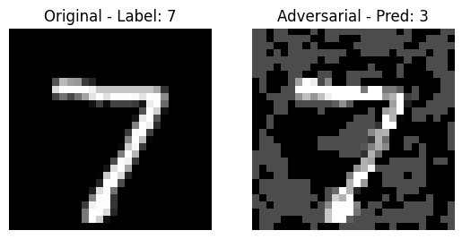

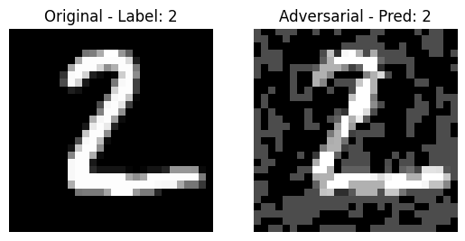

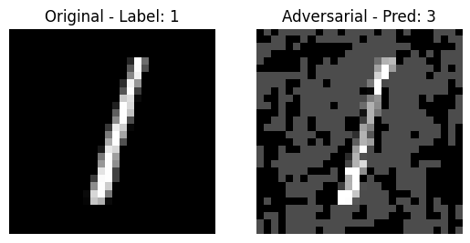

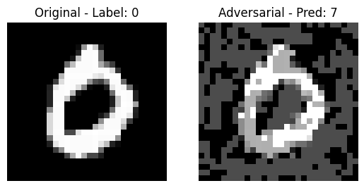

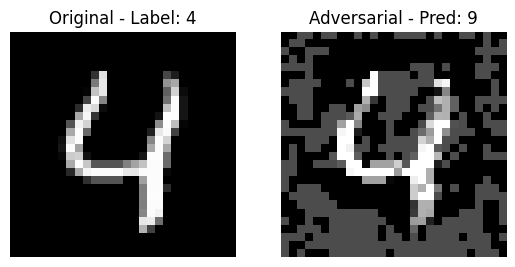

```python
eps = 0.3

correct = 0
total = 0
for images, labels in test_loader:
    # Generate adversarial images
    adv_images = fgsm_attack(model, images, labels, eps)

    # Re-classify
    outputs = model(adv_images.to(device))
    _, predicted = torch.max(outputs.data, 1)

    total += labels.size(0)
    correct += (predicted.cpu() == labels).sum().item()

adv_acc = 100 * correct / total
print(f"Accuracy on adversarial test images (FGSM, eps={eps}): {adv_acc:.2f}%")

###

examples = iter(test_loader)
example_images, example_labels = next(examples)
example_images = example_images[:5]
example_labels = example_labels[:5]

adv_ex = fgsm_attack(model, example_images, example_labels, eps)

for i in range(5):
    plt.figure()

    plt.subplot(1, 2, 1)
    plt.title(f"Original - Label: {example_labels[i].item()}")
    plt.imshow(example_images[i][0].cpu(), cmap="gray")
    plt.axis("off")

    adv_label_out = model(adv_ex[i].unsqueeze(0))
    _, adv_pred = torch.max(adv_label_out, 1)
    plt.subplot(1, 2, 2)
    plt.title(f"Adversarial - Pred: {adv_pred.item()}")
    plt.imshow(adv_ex[i][0].detach().cpu(), cmap="gray")
    plt.axis("off")

    plt.show()
```

```
Accuracy on adversarial test images (FGSM, eps=0.5): 10.91%
```

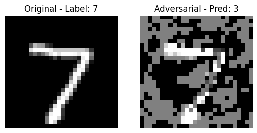

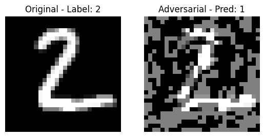

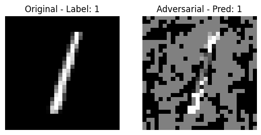

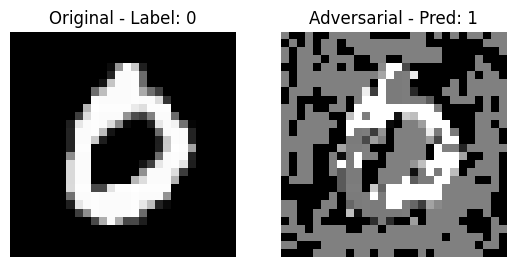

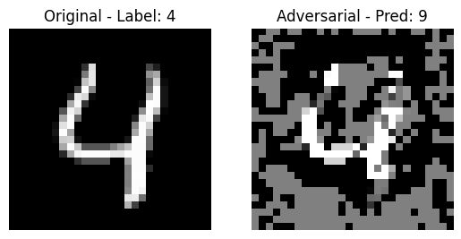

```python
eps = 0.5

correct = 0
total = 0
for images, labels in test_loader:
    # Generate adversarial images
    adv_images = fgsm_attack(model, images, labels, eps)

    # Re-classify
    outputs = model(adv_images.to(device))
    _, predicted = torch.max(outputs.data, 1)

    total += labels.size(0)
    correct += (predicted.cpu() == labels).sum().item()

adv_acc = 100 * correct / total
print(f"Accuracy on adversarial test images (FGSM, eps={eps}): {adv_acc:.2f}%")

###

examples = iter(test_loader)
example_images, example_labels = next(examples)
example_images = example_images[:5]
example_labels = example_labels[:5]

adv_ex = fgsm_attack(model, example_images, example_labels, eps)

for i in range(5):
    plt.figure()

    plt.subplot(1, 2, 1)
    plt.title(f"Original - Label: {example_labels[i].item()}")
    plt.imshow(example_images[i][0].cpu(), cmap="gray")
    plt.axis("off")

    adv_label_out = model(adv_ex[i].unsqueeze(0))
    _, adv_pred = torch.max(adv_label_out, 1)
    plt.subplot(1, 2, 2)
    plt.title(f"Adversarial - Pred: {adv_pred.item()}")
    plt.imshow(adv_ex[i][0].detach().cpu(), cmap="gray")
    plt.axis("off")

    plt.show()
```

```python
import numpy as np
eps_list = np.linspace(0, 0.8, 20)

accuracy = []

for eps in eps_list:
    correct, total = 0, 0
    for images, labels in test_loader:
        # Generate adversarial images
        adv_images = fgsm_attack(model, images, labels, eps)

        # Re-classify
        outputs = model(adv_images.to(device))
        _, predicted = torch.max(outputs.data, 1)

        total += labels.size(0)
        correct += (predicted.cpu() == labels).sum().item()

    adv_acc = 100 * correct / total
    print(f"Accuracy on adversarial test images (FGSM, eps={eps}): {adv_acc:.2f}%")
    accuracy.append(adv_acc)
#
```

```
Accuracy on adversarial test images (FGSM, eps=0.0): 97.54%
Accuracy on adversarial test images (FGSM, eps=0.042105263157894736): 71.50%
Accuracy on adversarial test images (FGSM, eps=0.08421052631578947): 49.03%
Accuracy on adversarial test images (FGSM, eps=0.12631578947368421): 37.51%
Accuracy on adversarial test images (FGSM, eps=0.16842105263157894): 30.77%
Accuracy on adversarial test images (FGSM, eps=0.21052631578947367): 25.92%
Accuracy on adversarial test images (FGSM, eps=0.25263157894736843): 22.46%
Accuracy on adversarial test images (FGSM, eps=0.29473684210526313): 19.22%
Accuracy on adversarial test images (FGSM, eps=0.3368421052631579): 16.65%
Accuracy on adversarial test images (FGSM, eps=0.37894736842105264): 14.70%
Accuracy on adversarial test images (FGSM, eps=0.42105263157894735): 13.04%
Accuracy on adversarial test images (FGSM, eps=0.4631578947368421): 11.73%
Accuracy on adversarial test images (FGSM, eps=0.5052631578947369): 10.79%
Accuracy on adversarial test images (FGSM, eps=0.5473684210526316): 9.98%
Accuracy on adversarial test images (FGSM, eps=0.5894736842105263): 9.17%
Accuracy on adversarial test images (FGSM, eps=0.631578947368421): 8.66%
Accuracy on adversarial test images (FGSM, eps=0.6736842105263158): 8.15%
Accuracy on adversarial test images (FGSM, eps=0.7157894736842105): 7.80%
Accuracy on adversarial test images (FGSM, eps=0.7578947368421053): 7.56%
Accuracy on adversarial test images (FGSM, eps=0.8): 7.26%
```

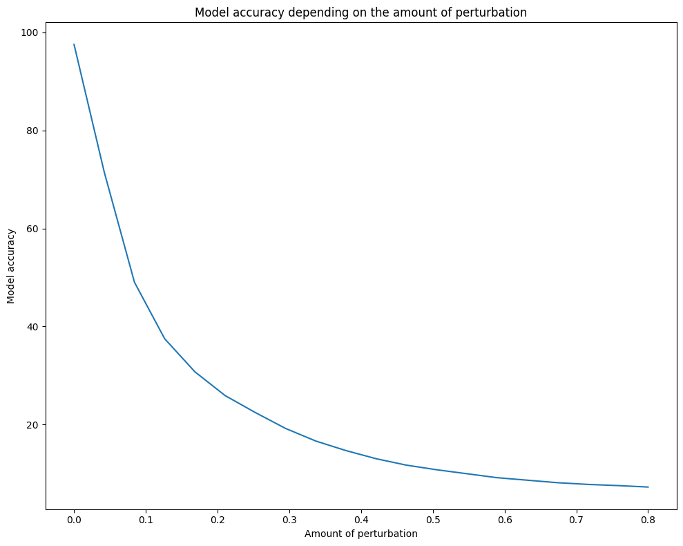

```python
plot_2d(eps_list, accuracy, title='Model accuracy depending on the amount of perturbation', xlabel='Amount of perturbation', ylabel='Model accuracy')
```

Wizualna zmiana danych po zastosowaniu FGSM zależy od wartości przyjętego $\epsilon$. Im wartosć większa, tym zmienione dane coraz mniej przypominają dane wejściowe. Z kolei, w takim przypadku, dokładność modelu jest znacznie mniejsza. Widać tutaj zależność odwrotnie proporcjonalną - wzrost $\epsilon$ to spadek jakości modelu i odwrotnie. Dzięki zastosowaniu FGSM można w bardzo łatwy sposób stworzyć dane, na których model sobie po prostu nie radzi. Dzięki FGSM widzę, że ocena jakości klasyfikatora nie jest taka prosta i mimo tego, że na zbiorze TESTOWYM klasyfikator świetnie sobie radzi, to zawsze można szybko wygenerować takie próbki, dla których będzie tragiczny. Może to mieć ciekawe lub niebezpieczne zastosowanie, jeśli takie modele będą używane na codzień np. w gałęziach przemysłu lub motoryzacji.